# BMET5933 Assignment 2 — Demo Summary

### Deep Learning Technical Contribution · James Wu

This is the slim demo notebook for the kidney CT classification project. It mirrors my PowerPoint deck section-by-section so I can fall back to it if I am not allowed to use slides during the demo. I keep only the meaningful code snippets — full implementations and exhaustive analyses live in `James_Wu_Deep_Learning_Technical_Contribution.ipynb` and in the `Planning/` vault.

**Project**: 4-class kidney CT classification (Cyst / Normal / Stone / Tumor) on the Islam et al. 2022 benchmark. **Team**: Anthony Lee (classical handcrafted features + SVM) and James Wu (me, transfer-learned CNNs). **My contribution**: the entire deep-learning pipeline plus the shared preprocessing and the leakage diagnostic.

## 1. Shared infrastructure (what both pipelines use)

Both Anthony's classical SVM and my deep-learning models share the same data loader and the same evaluation harness. I designed these jointly with Anthony in Phase 0 so the classical-vs-DL comparison is apples-to-apples.

The key shared building block is `load_image()` — every CT slice enters the system through this function before any pipeline-specific work happens.

```python
# Section 1 — shared image loader. Used by both pipelines.

# (bootstrap) Add the project root to sys.path so `from shared.config import ...`
# works when this notebook is executed from inside the notebooks/ folder.
import sys
from pathlib import Path
_here = Path.cwd()
if not (_here / "shared").exists() and (_here.parent / "shared").exists():
    sys.path.insert(0, str(_here.parent))

# `PIL` = Python Imaging Library (fork "Pillow"). `Image` is the submodule
# that gives us .open(), .convert(), .crop(), .resize() etc.
from PIL import Image

# `numpy` is aliased as `np`. Used to return the final image as a
# uint8 array — downstream pipelines expect numpy, not PIL objects.
import numpy as np

# `IMAGE_SIZE` is a project-wide constant defined in shared/config.py.
# Its value is the tuple (256, 256) — the canonical working resolution.
from shared.config import IMAGE_SIZE


# `def` defines a function. `load_image` is the function name.
# `path` is a positional parameter: filesystem path (str or Path).
def load_image(path):
    # `Image.open(path)` lazily opens the file, returns a PIL Image.
    # "Lazy" = pixels not read from disk until .load()/.convert().
    # `.convert("L")` converts the image mode to "L" = 8-bit single-channel
    # luminance (greyscale). CT scans are intrinsically intensity; we don't
    # want to fake RGB at this stage.
    img = Image.open(path).convert("L")

    # `.size` is a (width, height) tuple of the PIL Image.
    # Tuple-unpacking assigns the two ints to local names `w` and `h`.
    w, h = img.size

    # `min(w, h)` is the Python built-in: pick the smaller of the two.
    # `m` will become the side length of the square we crop out.
    m = min(w, h)

    # Compute the (left, top) corner so the crop is centered on the image.
    # Integer division `//` gives the floor; `.crop` needs int coords.
    left = (w - m) // 2
    top = (h - m) // 2

    # `.crop((left, top, right, bottom))` returns a new PIL Image with
    # the rectangle from (left, top) to (left+m, top+m). 4-tuple is a PIL
    # convention; coordinates are pixel positions, not percentages.
    img = img.crop((left, top, left + m, top + m))

    # `.resize(size, resample)` returns a PIL Image at the new size.
    # `IMAGE_SIZE` = (256, 256). `Image.BILINEAR` is the resampling filter:
    # weighted avg of 4 nearest pixels; smooth and edge-preserving;
    # standard for medical imaging.
    img = img.resize(IMAGE_SIZE, Image.BILINEAR)

    # `np.asarray(img, dtype=np.uint8)` converts the PIL Image into a numpy
    # array with shape (H, W) = (256, 256) and dtype uint8 (values 0-255).
    # `asarray` (vs `array`) avoids copying when already an ndarray.
    return np.asarray(img, dtype=np.uint8)
```

*The cell above defines `load_image()`. No output is expected — this is a function definition. Calling it would return a 256×256 uint8 numpy array of one CT slice.*

**Why this matters for my demo:** the deep-learning input pipeline and the classical feature-extraction pipeline both start from the same 256×256 grayscale uint8 array. Differences from here on are intentional, not accidents of preprocessing.

## 2. Dataset and split

After deduplication (more on this in Section 8), the benchmark contains 11,929 unique CT slices across four classes. I work from the same `split_full.csv` that Anthony's pipeline uses — train/val/test = 8,146 / 1,895 / 1,888, stratified by class with patient-group buckets so adjacent slices from the same patient stay together.

```python
# Section 2 — confirm the split I report against.

# `pandas` is aliased as `pd`. Standard tabular-data library; we
# use it to read the CSV and build the summary table.
import pandas as pd
# `pathlib.Path` is Python's modern OO path API — replaces os.path string
# manipulation with operator-overloaded path objects.
from pathlib import Path

# `Path.cwd()` returns the current working directory as a Path object.
ROOT = Path.cwd()

# If the notebook is opened from inside notebooks/, hop one level up.
# `(ROOT / "split_full.csv")` uses the `/` operator that Path overloads to
# join path components — equivalent to os.path.join.
# `.exists()` returns True/False without touching the file contents.
# `ROOT.parent` is the parent directory (one level up).
if (not (ROOT / "split_full.csv").exists()
        and (ROOT.parent / "split_full.csv").exists()):
    ROOT = ROOT.parent

# `pd.read_csv(path)` reads a CSV file into a pandas DataFrame.
# The DataFrame has columns "filename", "class", "split".
split = pd.read_csv(ROOT / "split_full.csv")

# Build the per-(split, class) count summary.
# `.groupby(["split", "class"])` groups rows by both columns (multi-index).
# `.size()` returns a Series of counts per group.
# `.unstack(fill_value=0)` pivots the "class" level into columns; any
# missing (split, class) combination becomes 0 instead of NaN.
# `.reindex(columns=[...])` enforces the canonical column order so Cyst
# always comes first regardless of pandas's internal alphabetical sort.
summary = (
    split.groupby(["split", "class"]).size()
    .unstack(fill_value=0)
    .reindex(columns=["Cyst", "Normal", "Stone", "Tumor"])
)

# Add a "Total" column = sum across each row (axis=1 means row-wise sum).
summary["Total"] = summary.sum(axis=1)

# `print()` writes the DataFrame to stdout. Default formatting is
# space-aligned columns, fine for a console demo.
print(summary)
```

```
class  Cyst  Normal  Stone  Tumor  Total
split
test    513     777    248    350   1888
train  2233    3436    894   1583   8146
val     538     789    218    350   1895
```

I deliberately do not touch the held-out test set during training or checkpoint selection — every test number I report is from a single inference pass on the final model.

## 3. Architecture choice — two CNN backbones

I picked two backbones for the deep-learning side: **EfficientNet-B0** (5M parameters, my baseline) and **ConvNeXt V2 Base** (89M parameters, my primary model). They share the same data, same protocol, same evaluation harness, so the comparison isolates the architecture-and-pretraining effect.

I chose these specifically because:

- EfficientNet-B0 is small enough to fit comfortably in memory and trains fast, giving me a solid lightweight baseline.
- ConvNeXt V2 Base has ImageNet-22k → 1k pretraining and is a modern CNN that competes with vision transformers — I wanted to test whether more capacity and stronger pretraining help on this benchmark.

```python
# Section 3 — model builders. Single dispatcher style so I can swap
# backbones with one CLI flag (--model efficientnet_b0 or convnextv2_base).

# `torch.nn` is the PyTorch submodule for neural-network layers (Linear,
# Conv2d, Dropout, Sequential, ...). `nn` is the conventional alias.
import torch.nn as nn

# `torchvision.models` ships pretrained CNN architectures. We import the
# constructor `efficientnet_b0` and weight-enum `EfficientNet_B0_Weights`
# that maps a string ("IMAGENET1K_V1") to a pretrained checkpoint.
from torchvision.models import EfficientNet_B0_Weights, efficientnet_b0

# `timm` (PyTorch Image Models) is the standard library for modern
# vision backbones with pretrained weights. We use it for ConvNeXt V2.
import timm


# `def` declares a function. `build_efficientnet_b0` returns a model ready
# for fine-tuning. `num_classes=4` is a keyword argument with default 4.
def build_efficientnet_b0(num_classes=4):
    # `EfficientNet_B0_Weights.IMAGENET1K_V1` selects the v1 ImageNet-1k
    # pretrained weights checkpoint provided by torchvision.
    weights = EfficientNet_B0_Weights.IMAGENET1K_V1

    # `efficientnet_b0(weights=weights)` instantiates the architecture and
    # downloads/applies the pretrained weights to every layer including the
    # original 1000-class ImageNet head.
    model = efficientnet_b0(weights=weights)

    # `model.classifier` is the final classifier head — a Sequential
    # containing [Dropout, Linear(in_features, 1000)].
    # `[1]` indexes the Linear layer; `.in_features` reads its input dim
    # (1280 for EfficientNet-B0).
    in_features = model.classifier[1].in_features

    # Replace the 1000-class head with our own 4-class head.
    # `nn.Sequential` chains layers in order.
    # `nn.Dropout(p=0.3)` randomly zeros 30% of activations in training
    # for regularisation; turned off automatically during model.eval().
    # `nn.Linear(in_features, num_classes)` is the final fully-connected
    # layer mapping 1280-dim features to our 4 logits.
    model.classifier = nn.Sequential(
        nn.Dropout(p=0.3),
        nn.Linear(in_features, num_classes),
    )

    # Return the modified model (still has the pretrained backbone weights;
    # only the head is freshly initialised).
    return model


# Builder for the larger backbone. `image_size=384` is our default because
# ConvNeXt V2 was pretrained at 384.
def build_convnextv2_base(num_classes=4, image_size=384):
    # Pick the matching pretrained checkpoint by name. timm uses dotted
    # of the form "<arch>.<pretrain_tag>".
    # "fcmae_ft_in22k_in1k_384" decodes as:
    #   fcmae        = Fully Conv. Masked AutoEncoder (self-supervised
    #                  pretraining used by ConvNeXt V2)
    #   ft_in22k     = fine-tuned on ImageNet-22k (~14M imgs, 22k cls)
    #   in1k         = fine-tuned on ImageNet-1k (1.28M imgs, 1000 cls)
    #   _384         = final input resolution 384x384
    name = (
        "convnextv2_base.fcmae_ft_in22k_in1k_384"
        if image_size >= 384
        else "convnextv2_base.fcmae_ft_in22k_in1k"
    )

    # `timm.create_model(name, pretrained=True, ...)` downloads and applies
    # the weights. The remaining kwargs are timm's regularisation options:
    #   num_classes=4    -> replace the head with a 4-class Linear
    #   drop_path_rate   -> stochastic depth: prob of randomly dropping
    #                       a whole residual branch in training. 0.3 is
    #                       a standard value for an 89M-parameter model on
    #                       ~8k training images.
    #   drop_rate        -> head dropout (before the final Linear).
    return timm.create_model(
        name,
        pretrained=True,
        num_classes=num_classes,
        drop_path_rate=0.3,
        drop_rate=0.3,
    )
```

*The cell above defines two model builders. Each call returns a PyTorch `nn.Module` ready for fine-tuning with the new 4-class head in place of the original ImageNet classifier.*

## 4. Two-stage transfer learning

I train each backbone in two stages:

1. **Stage 1 (5 epochs)** — freeze the backbone, train only the new classifier head with Adam at LR 1e-3. This lets the head reach a reasonable starting point without disturbing the ImageNet features.
2. **Stage 2 (60 epochs)** — unfreeze the last stage of the backbone, switch to AdamW with cosine learning-rate schedule (5-epoch warmup, peak 1e-5, anneal to 1e-7). Class-weighted cross-entropy compensates for the imbalance (Stone is roughly 3.7× rarer than Normal).

I save the checkpoint with the best validation macro-F1, not the final epoch.

```python
# Section 4 — skeleton of my two-stage training loop.
# Full code lives in deep_learning/train.py — this is the demo cut.

# `Adam` is the original adaptive-moment optimizer. We use it for stage 1
# (head only) — Adam works fine when no weight decay is needed.
# `AdamW` is Adam with decoupled weight decay (Loshchilov+Hutter 2019),
# which is the correct way to apply L2-like regularisation in adaptive
# optimizers. We use AdamW for stage 2.
from torch.optim import Adam, AdamW

# Learning-rate schedulers.
# `CosineAnnealingLR(optimizer, T_max, eta_min)` decays LR from its initial
#   value down to `eta_min` along the first half of a cosine curve.
#   T_max is the number of epochs in the cosine phase.
# `LinearLR(optimizer, start_factor, end_factor, total_iters)` linearly
#   ramps LR from start_factor * base_lr up to end_factor * base_lr over
#   `total_iters` epochs. We use it for the 5-epoch warmup.
# `SequentialLR(optimizer, schedulers, milestones)` chains schedulers — it
#   applies the first one until the milestone epoch, then switches to the
#   next one. We chain warmup then cosine.
from torch.optim.lr_scheduler import (
    CosineAnnealingLR,
    LinearLR,
    SequentialLR,
)


# ── Stage 1 ────────────────────────────────────────────────────
# Freeze every backbone parameter so only the new head trains.
# `freeze_backbone(model)` is my helper (deep_learning/model.py) that sets
# `requires_grad = False` on backbone layers, `requires_grad = True`
# on the head. Frozen tensors have no gradient computation and contribute
# zero memory to autograd.
freeze_backbone(model)

# Build the optimizer only over the parameters that still require gradient.
# `model.parameters()` yields ALL parameters (frozen and trainable).
# The list comprehension `[p for p in ... if p.requires_grad]` filters to
# the head parameters only — Adam shouldn't update frozen weights.
# `lr=1e-3` is the head-warmup learning rate (high because we want the
# fresh head to reach a sensible starting point quickly).
optimizer = Adam(
    [p for p in model.parameters() if p.requires_grad],
    lr=1e-3,
)

# Train for 5 epochs. `range(5)` produces 0, 1, 2, 3, 4.
for epoch in range(5):
    # `train_one_epoch(...)` is my helper that runs one full pass over the
    # training DataLoader: forward, loss, backward, optimizer.step().
    train_one_epoch(model, train_loader, optimizer, loss_fn)

    # `evaluate_macro_f1(...)` is my helper that runs the model on the
    # validation DataLoader and returns sklearn macro-F1 over predictions.
    val_f1 = evaluate_macro_f1(model, val_loader)

    # Save the checkpoint only if it improved the validation metric.
    # `torch.save(state_dict, path)` serialises the model weights (not the
    # full nn.Module) to a .pt file. state_dict = dict of tensors.
    if val_f1 > best_val_f1:
        torch.save(model.state_dict(), ckpt_path)


# ── Stage 2 ────────────────────────────────────────────────────
# Unfreeze the last `n_blocks` backbone stages so they get fine-tuned.
# n_blocks=1 for ConvNeXt V2 (bigger stages), n_blocks=2 for
# EfficientNet-B0 (smaller stages). Earlier stages stay frozen because the
# low-level ImageNet features transfer well as-is.
unfreeze_last_blocks(model, n_blocks=1)

# Switch to AdamW with stronger weight decay.
# `weight_decay=5e-2` is heavy regularisation for ConvNeXt V2's 89M params.
# For EfficientNet-B0 (5M params) I use 1e-4 — smaller models need less
# decoupled decay to avoid under-fitting.
# `lr=1e-5` is the peak LR after warmup; chosen 100x smaller than stage 1
# because we're now updating pretrained weights with small nudges.
optimizer = AdamW(
    [p for p in model.parameters() if p.requires_grad],
    lr=1e-5,
    weight_decay=5e-2,
)

# Linear warmup for 5 epochs: LR ramps from 1% of peak (0.01 * 1e-5 = 1e-7)
# up to 100% of peak (1e-5). Without warmup, the first big gradient step on
# the still-fragile head can destabilise the pretrained backbone.
warmup = LinearLR(
    optimizer,
    start_factor=0.01,
    end_factor=1.0,
    total_iters=5,
)

# Cosine anneal over the remaining 55 epochs: LR drops smoothly from peak
# 1e-5 down to eta_min=1e-7. Cosine is empirically kinder to pretrained
# weights than step decay or constant LR.
cosine = CosineAnnealingLR(optimizer, T_max=55, eta_min=1e-7)

# `SequentialLR` runs `warmup` first, then switches to `cosine` at epoch 5
# (the milestone). The optimizer's LR is updated every time we call
# `scheduler.step()` at the end of an epoch.
scheduler = SequentialLR(optimizer, [warmup, cosine], milestones=[5])

# Train for 60 epochs total in stage 2 (5 warmup + 55 cosine).
for epoch in range(60):
    train_one_epoch(model, train_loader, optimizer, loss_fn)
    val_f1 = evaluate_macro_f1(model, val_loader)
    if val_f1 > best_val_f1:
        torch.save(model.state_dict(), ckpt_path)
    # Advance the LR schedule one epoch.
    scheduler.step()
```

*The cell above is a code skeleton — it references `model`, `train_loader`, `loss_fn`, `freeze_backbone`, `evaluate_macro_f1`, and `ckpt_path` which are defined in `deep_learning/train.py`. The skeleton is shown here because the full training loop runs for ~50 minutes on a GPU and is not re-executed during the demo.*

## 5. Inference and test-time augmentation

At inference I do two things beyond a plain forward pass:

1. **Save full softmax probabilities** (not just argmax predictions), because keeping probabilities lets me do paired McNemar's tests, soft-vote ensembles, and ROC-AUC without retraining.
2. **Horizontal-flip TTA**: predict on the original image, predict on the flipped image, average the two softmax vectors before argmax. Free accuracy boost at the cost of 2× inference time.

I tested rotation TTA too — it actually hurt accuracy, so I stuck with hflip only.

```python
# Section 5 — inference with horizontal-flip TTA.
# Key idea: average softmax distributions, not argmaxes. Argmax-avg
# throws away the model's confidence — softmax-averaging keeps it.

import torch
import numpy as np
from PIL import Image

# `@torch.no_grad()` is a decorator that disables PyTorch's autograd engine
# inside the function. Saves memory + time; no gradient tracking
# gradients during inference. Equivalent to wrapping the body in a
# `with torch.no_grad():` block.
@torch.no_grad()
def predict_with_tta(model, image_uint8):
    # `model.eval()` switches BatchNorm/Dropout into evaluation mode:
    #   - Dropout becomes a no-op (don't zero activations at inference).
    #   - BatchNorm uses running statistics instead of batch statistics.
    # ConvNeXt uses LayerNorm so the BN part doesn't matter here, but
    # calling .eval() is the safe default for any model.
    model.eval()

    # Build the two TTA views.
    # `Image.fromarray(image_uint8, mode='L')` wraps the np array into
    # a PIL Image so we can use PIL's .transpose() for flipping. mode='L'
    # tells PIL it's single-channel grayscale.
    pil = Image.fromarray(image_uint8, mode="L")

    # `.transpose(Image.FLIP_LEFT_RIGHT)` returns a new PIL Image that is
    # the horizontal mirror. PIL's transpose constant FLIP_LEFT_RIGHT does
    # exactly what its name suggests — flips along the vertical axis.
    flip = pil.transpose(Image.FLIP_LEFT_RIGHT)

    # Apply the standard val transform (resize + ImageNet-normalise +
    # 3-channel-replicate) to each view, then add a batch dimension with
    # `.unsqueeze(0)` so the model sees a (1, 3, H, W) tensor.
    # `.to(device)` ships the tensor to the GPU (cuda/mps) if available.
    x_orig = transform(np.asarray(pil)).unsqueeze(0).to(device)
    x_flip = transform(np.asarray(flip)).unsqueeze(0).to(device)

    # Forward pass on each view. `model(x)` returns raw logits of shape
    # (batch, num_classes) = (1, 4).
    # `torch.softmax(logits, dim=1)` converts logits to probabilities along
    # the class dimension (each row sums to 1).
    p_orig = torch.softmax(model(x_orig), dim=1)
    p_flip = torch.softmax(model(x_flip), dim=1)

    # Average the two probability vectors -- heart of soft-vote TTA.
    p_avg = (p_orig + p_flip) / 2

    # `.argmax(dim=1)` -> class index with the highest averaged prob.
    # `.item()` extracts a Python scalar from a 0-dim tensor.
    # `.cpu().numpy()` moves the tensor back to CPU and converts
    # it to a numpy array so the caller can pickle or use it w/ sklearn.
    return p_avg.argmax(dim=1).item(), p_avg.cpu().numpy()
```

*The cell above defines `predict_with_tta()`. Calling it on a single CT slice would return a tuple `(predicted_class_index, averaged_softmax_probs)`.*

## 6. Headline numbers (clean held-out test set, n = 1,888)

I report macro-F1 because the class distribution is imbalanced (Stone ~13 %, Normal ~41 %) — accuracy would over-weight the easy majority class.

```python
# Section 6 — load the four pre-computed result JSONs and display them.

# `json` is Python's built-in JSON parser; loads our .json files
# my predict scripts saved.
import json
# `Path` again for path joining.
from pathlib import Path
# `pd` for tabular display.
import pandas as pd

# `RESULTS` points at the Results/ directory inside the project root.
# (`ROOT` was set in Section 2.)
RESULTS = ROOT / "Results"

# `models` is a dict mapping display name -> relative path to the JSON file
# under Results/. Using a dict (vs two parallel lists) makes the loop below
# read more naturally.
models = {
    "EfficientNet-B0":
        "dl_run_full/dl_results.json",
    "EfficientNet-B0 + hflip TTA":
        "dl_run_full_tta_hflip/dl_results.json",
    "ConvNeXt V2 Base":
        "convnextv2_full_run/dl_results.json",
    "ConvNeXt V2 Base + hflip TTA":
        "convnextv2_full_run_tta_hflip/dl_results.json",
}

# `rows` is a list of dicts; each dict becomes one DataFrame row.
rows = []

# `.items()` iterates over (key, value) pairs of the dict.
for name, rel in models.items():
    # `(RESULTS / rel)` joins the result-dir Path with the relative path.
    # `.read_text()` returns the file contents as a single string.
    # `json.loads(s)` parses a JSON string into a Python dict.
    r = json.loads((RESULTS / rel).read_text())

    # Build one row of the table. `.append(dict)` adds to the list.
    # `round(x, 4)` truncates the float to 4 decimal places for display.
    rows.append({
        "Model": name,
        "Accuracy": round(r["accuracy"], 4),
        "Macro-F1": round(r["macro_f1"], 4),
        # `r["per_class"]["Stone"]["f1"]` is a nested-dict lookup into the
        # JSON's per-class breakdown for the Stone class's F1 score.
        "Stone F1": round(r["per_class"]["Stone"]["f1"], 4),
    })

# `pd.DataFrame(rows)` builds a DataFrame from a list of dicts.
# In a Jupyter cell, evaluating a DataFrame as the last expression
# automatically calls its HTML representation for nice rendering.
pd.DataFrame(rows)
```

|  | Model | Accuracy | Macro-F1 | Stone F1 |
| --- | --- | --- | --- | --- |
| 0 | EfficientNet-B0 | 0.8014 | 0.7679 | 0.6102 |
| 1 | EfficientNet-B0 + hflip TTA | 0.8263 | 0.7945 | 0.6613 |
| 2 | ConvNeXt V2 Base | 0.8538 | 0.8219 | 0.6980 |
| 3 | ConvNeXt V2 Base + hflip TTA | 0.8665 | 0.8370 | 0.7171 |

ConvNeXt V2 + TTA is my best single deep-learning model at macro-F1 0.837. EffNet-B0 + TTA is 0.795. For comparison, Anthony's classical SVM reaches macro-F1 0.909 on the same test set — classical wins on this clean benchmark.

## 7. Per-class results — Stone is the universal weak class

Stone is the lowest-F1 class for every model I trained. The dominant error type is `Stone → Normal`, because small focal calcifications get diluted when a whole-slice CNN classifier pools over the entire image.

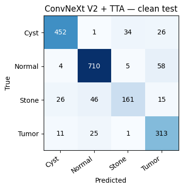

```python
# Section 7 — confusion matrix for my best DL model.

# `numpy` for converting JSON list-of-lists to a 2D array.
import numpy as np
# `matplotlib.pyplot` is the standard plotting API; aliased as `plt`.
import matplotlib.pyplot as plt

# Load the same result JSON used in Section 6 (just the ConvNeXt+TTA one).
r = json.loads(
    (RESULTS / "convnextv2_full_run_tta_hflip"
     / "dl_results.json").read_text()
)
# `r["confusion_matrix"]` is a 4x4 list-of-lists; we convert to numpy so
# `.max()`, indexing, and matplotlib's `.imshow()` work cleanly.
cm = np.array(r["confusion_matrix"])

# Class labels in the canonical project order.
classes = r["classes"]

# `plt.subplots(figsize=(W,H))` creates one figure and one axis. size is
# in inches (5 wide x 4 tall).
fig, ax = plt.subplots(figsize=(5, 4))

# `ax.imshow(cm, cmap="Blues")` draws the confusion matrix as a heatmap.
# `cmap="Blues"` maps low values to white, high values to dark blue.
# Returns the AxesImage handle (`im`) for an optional colorbar later.
im = ax.imshow(cm, cmap="Blues")

# Replace the integer tick labels with the class names.
# `rotation=35` rotates by 35 degrees; `ha="right"` aligns the label so the
# right end sits at the tick (avoids overlap).
ax.set_xticks(range(4), classes, rotation=35, ha="right")
ax.set_yticks(range(4), classes)
ax.set_xlabel("Predicted")
ax.set_ylabel("True")
ax.set_title("ConvNeXt V2 + TTA — clean test")

# Annotate each cell of the matrix with its count.
# Outer loop over rows (true class), inner loop over columns (predicted).
for i in range(4):
    for j in range(4):
        # Choose readable text colour: white on dark cells, black on light.
        # `cm.max() * 0.55` is the threshold; >55% of max gets the
        # matrix maximum gets white text (so it's visible on dark blue).
        color = "white" if cm[i, j] > cm.max() * 0.55 else "black"

        # `ax.text(x, y, s, ...)` places text. Coords are data units
        # (column index, row index). `ha`/`va` are horizontal/vertical
        # alignment so the text is centered in the cell.
        ax.text(j, i, str(cm[i, j]), ha="center", va="center", color=color)

# Auto-adjust subplot params to prevent label clipping.
plt.tight_layout()
# Render the figure inline in the notebook.
plt.show()
```

## 8. The leakage diagnostic — my headline finding

While exploring the dataset I noticed our DL models were hitting accuracies that looked too good (EfficientNet-B0 at 0.94, ConvNeXt V2 at 1.000). I wrote a small script that MD5-hashes every standardised pixel array and compares the train, val, and test sets for collisions.

I found **5.1 % of test images were bit-for-bit identical to training images** — 96 out of 1,867 hash collisions. The dataset author independently confirmed the duplicates two days later and released a deduplicated version, which is the dataset I use everywhere else in this notebook.

Deep networks were memorising the duplicated images; classical handcrafted features were not. That's the strongest evidence I have that prior reported 99 %+ accuracies on this benchmark are inflated.

```python
# Section 8 — the leakage detection function. This is the heart of my
# headline finding.

# `hashlib` is Python's built-in crypto-hash library; we use MD5
# because it's fast and has near-zero collision prob for distinct
# (~10^-38), and gives a 32-character hex string per image — perfect for
# set-intersection comparisons.
import hashlib
# `Counter` from collections counts repeated occurrences of items in a
# sequence; used in the actual script to find within-split dups.
from collections import Counter

def md5_image(path):
    # Critical design choice: I hash the STANDARDISED pixel buffer, not the
    # raw JPEG bytes. Two JPEGs with different compression settings
    # but identical pixel content still collide. Two identical files with
    # different EXIF metadata also collide. We're checking *image content
    # equality after our preprocessing*, which is what actually matters for
    # train/test contamination.
    img = load_image(path)   # the shared loader from Section 1

    # `img.tobytes()` returns the raw bytes of the underlying numpy buffer.
    # For a (256, 256) uint8 array this is exactly 65,536 bytes.
    # `hashlib.md5(b)` returns a hash object; `.hexdigest()` returns its
    # 32-character lowercase hex representation, e.g. "0c4a9b3e..." .
    return hashlib.md5(img.tobytes()).hexdigest()

# In the real diagnostic I ran this in parallel over ~12k images via
# joblib.Parallel, then intersected the per-split hash sets to count
# collisions. Conceptually:
#
#     train_hashes = {md5_image(p) for p in train_paths}  # set comp.
#     test_hashes  = {md5_image(p) for p in test_paths}
#     duplicates   = train_hashes & test_hashes        # set intersection
#                                                       # `&` on sets =
#                                                       # common elements
#
# `{ ... for ... in ... }` is a set comprehension. Sets give O(1) average
# membership and intersection.
#
# Result on the original Islam et al. 2022 release:
#   96 / 1,867 test images had a bit-identical training-set sibling = 5.1%
#
# That 5.1% number is what I report as my headline finding.
```

*The cell above defines `md5_image()`. The actual full diagnostic (parallel over ~12k images) lives at `analysis/diag_image_hash_leakage.py`. Running it on the original Islam et al. 2022 release found 96 / 1,867 bit-identical train↔test image pairs — the 5.1 % leakage rate I report.*

## 9. Summary of what I built

In bullet form (this is roughly the closing slide of my demo):

- **Shared layer** I co-designed with Anthony: `load_image()`, `load_split()`, `bootstrap_ci()`, paired McNemar's test.
- **My deep-learning code**: EfficientNet-B0 and ConvNeXt V2 builders, two-stage transfer learning with cosine LR + warmup, class-weighted CE, inference with hflip TTA, multi-seed ensembling, Grad-CAM interpretation.
- **My most novel finding**: the MD5 leakage diagnostic — discovered 5.1 % bit-identical train↔test duplication that previously-published 99 %+ accuracies were silently relying on.
- **Honest conclusion**: on the cleaned benchmark, Anthony's classical SVM beats both of my deep-learning models by 7 to 14 percentage points. Deep networks aren't free-lunch superior here; they're more leakage-sensitive and have lower sample efficiency.

The full technical detail and every artefact lives in `James_Wu_Deep_Learning_Technical_Contribution.ipynb` and the `Planning/` vault. This summary notebook is just the demo-friendly cut.